# Bacterium adaptation

Analysis of “More than 6,000 antibiotic resistance genes discovered in the bacteria that inhabit the human gut”

Student Unknown , Nicolas Devilez , Engels Guyliann https://guyliann.netlify.com/fr  
10-24-2019

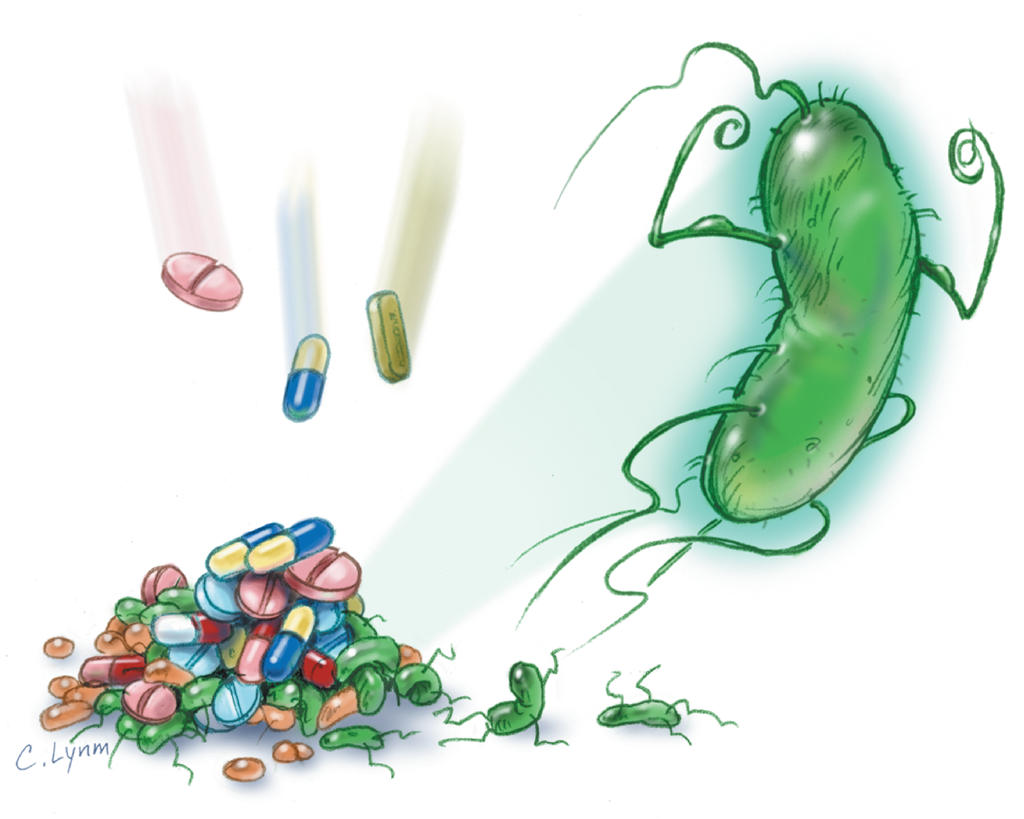

This post is an analysis of Analysis of *More than 6,000 antibiotic resistance genes discovered in the bacteria that inhabit the human gut* (University of Birmingham 2018).

## Summary

Bacterium adaptation to the surrounding environment is an undeniable and growing phenomenon. Nevertheless, some of these adaptations concern researchers because they pose a real threat to human health and are the origin of an increasing number of deaths each year.

Are all these bacteria originally dangerous? It’s a halftone answer. On the one hand, some bacteria have caused deadly infectious diseases for centuries such as staph but their rising dangerousness over the years is only the result of human errors. Where bacteria adapt to human innovations in order to survive, human has increasingly difficulties to counter the adaptive response of bacteria. The phenomenon is extremely important in the case of drug-resistant bacteria called “superbugs”. By prescribing antibiotics in an abusive way, bacteria have gradually succeeded, by their defense mechanisms such as the horizontal genes transfer or the transformation of their body wall, in dodging them to such an extent that some antibiotics, such as the Vancomycin, are totally useless against some bacteria.

## Vocabulary:

| Words from the text | Synonym / explanation in English |
| --- | --- |
| To inhabit | To live in |
| Gut | Intestine |

## Analysis table

[output not shown]

University of Birmingham. 2018. “More than 6,000 antibiotic resistance genes discovered in the bacteria that inhabit the human gut.” www.sciencedaily.com/releases/2018/11/181130111626.htm.